# Analysis of deer data using the PMoveSTIR framework

Juan S Vargas

2023-09-08

# Introduction

We have developed a framework to estimate the expected FOI from movement data (e.g. GPS collar data). The original position data is used to create individual utilization distributions, and to estimate the cross-correlation in space use. The process is as follows:

1. Estimate utilization distributions. This could be done using autocorrelated kernel density estimations based on continuous-time movement models, or regular kernel density estimations. The grid over which the UDs are estimated is made up of square cells with side length equal to $d$, the epidemiological contact distance. We assume a uniform contact probability if both individuals are in the same cell.
2. For every cell, calculate the product of the UDs and the SDs. It is important here that the values we are using represent the total probability per cell, i.e. the probability density function integrated over the area of the cell. In the UD objects of ctmm this corresponds to the PMF (Probability Mass Function), and is equal to the average PDF per cell multiplied by the cell area.
3. Get the position history for every individual. As a first step we interpolate the trajectories so that the timestamps are the same for both individuals in a pair.
4. Calculate the correlation in presence for every cell and every pair, at different lags.
5. Scale the values by the parasite survival function. Here we assume a constant rate of decay $\nu$, represented by an exponential function $S(t)=e^{-\nu t}$. The decay process also scales the product of the UDs. This value is approximated by $1/\nu$.

```r
# Load libraries
library(tidyverse)
library(raster)
library(move)
library(ctmm)
```

## Parameters

Set epidemiological parameters: threshold contact distance and parasite decay rate. These parameters influence the size of the area $x$ in which contact can occur, and how long the parasite persists in the environment. We also set the transmission parameter $\beta$ and the deposition rate $\lambda$. These are important for the estimation of the absolute value of FOI, but they are scalars so they don’t matter much for comparative analyses.

```r
contact_dist <- 10 # meters
nu <- 1/(3600*24*7)# 7 days, in seconds
beta <- 1 # search efficiency, m^2/s
lam <- 1/(3600*2) # deposition rate, s^-1
```

## Load and prepare data

```r
# Import data
dat_raw <- read.csv("../data/cleaned_movement_data_07132023.csv")
# the data has 13 columns: animal id, x, y, time, dop (error), capture method,
# lat and long, age, sex, duplicate animal_id x_ y_ t_ dop method_of_capture
# lat_capture long_capture age sex duplicate_ fast_step_ fast_roundtrip_
# I'll remove locations flagged as unrealistically fast steps
dat1 <- dat_raw[!(dat_raw$fast_step_ | dat_raw$fast_roundtrip_),]

# filter to keep only a subset of individuals
ids <- c("151564","151571","151589","151592","151599")
dat1 <- dat1[dat1$animal_id %in% ids,]

# Remove also some initial locations that were collected before the collars were
# on the animals (during storage and transport), these show up as points outside
# of the core areas on the road and in a town, east of ~ 306000
dat1 <- dat1[dat1$x_<306000,]
```

## Create move and telemetry objects.

The ctmm analysis requires an object of type `telemetry`, which can be created from a `move` object. We can create the move object from csv data.

```r
dat_move <- move(x = dat1$x_,y = dat1$y_,
                 time = as.POSIXct(dat1$t_, format = "%Y-%m-%dT%H:%M:%SZ", tz = "Etc/GMT-6"),
                 data = data.frame(HDOP=dat1$dop),
                 proj = "+proj=utm +zone=16N",
                 animal = dat1$animal_id)
telemetries <- as.telemetry(dat_move)
```

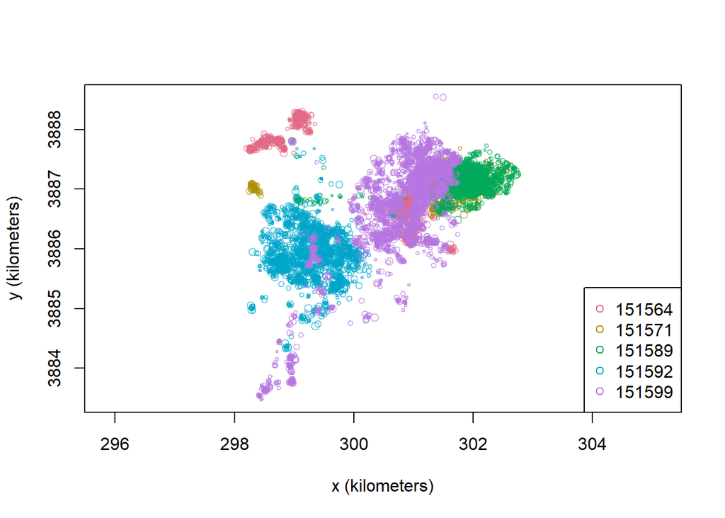

```r
plot(telemetries, col = hcl.colors(length(telemetries), "Dark 3"))
legend("bottomright", legend = ids, pch = 1, col = hcl.colors(length(telemetries), "Dark 3"))
```

# Utilization distribution

The utilization distribution can be obtained in two ways, 1) fitting a CTMM model to the movement data, and using autocorrelated kernel density estimation to obtain the UD, 2) using kernel density estimation. The latter does not account for autocorrelation in movement.

```r
# Fit a CTMM model to the trajectories
GUESS <- lapply(telemetries, \(i) ctmm.guess(i, interactive = F))
FITS <- lapply(seq_along(telemetries), \(i) ctmm.select(telemetries[[i]], GUESS[[i]]))
names(FITS) <- names(telemetries)
# export
saveRDS(FITS, "../outputs/deer_ctmm_fits.rds")
```

## Autocorrelated kernel density estimation

At this step you use the threshold distance set at the beginning as the resolution of the grid.

```r
FITS <- readRDS("../outputs/deer_ctmm_fits.rds")
for (i in seq_along(FITS)) {
  # file output name
  outname <- paste0("../outputs/", names(FITS)[i], ".tif")
  # create UD
  UD <- akde(data = telemetries[[i]], CTMM = FITS[[i]],
             grid = list(dr = c(contact_dist, contact_dist),
                         align.to.origin = TRUE))
  # save to disk. This saves the probability mass, not the density
  writeRaster(UD, outname, DF = "PMF", overwrite = TRUE)
  rm(UD)
}
```

## Kernel density estimation

We can also use simple kernel density estimation, which is much faster and often produces similar output. We use the `adehabitatHR` package, and transform the data to a SpatialPoints object.

```r
library(adehabitatHR)
# Create SpatialPoints object
dat_sp <- SpatialPointsDataFrame(coords = dat1[,c("x_","y_")], data = data.frame(id = dat1$animal_id))
# Create grid on which UD will be estimated
kde_grid <- SpatialGrid(grid = GridTopology(cellcentre.offset =bbox(dat_sp)[,1]-bbox(dat_sp)[,1]%%10, cellsize = c(contact_dist,contact_dist), cells.dim = ceiling(apply(bbox(dat_sp), 1, diff)/contact_dist)))
kde_grid_px <- SpatialPixels(SpatialPoints(coordinates(kde_grid)))
# Estimate UD
ud_kde <- kernelUD(dat_sp, grid = kde_grid_px)
```

How similar are the estimated UDs? Here is one example.

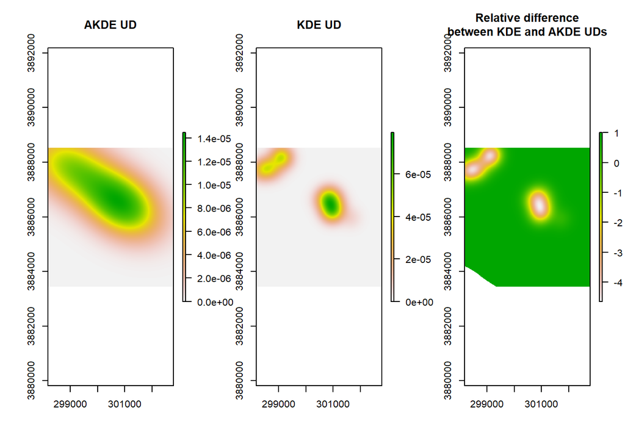

```r
ud_kde_rasts <- lapply(ud_kde,raster)
par(mfrow = c(1,3))
with(list(a = raster(list.files("../outputs/", "X(.*)tif$", full.names = T)[1]),
          b = ud_kde_rasts[[1]]*contact_dist^2),{
            raster::plot(crop(a,b), main = "AKDE UD")
            raster::plot(b, main = "KDE UD")
            raster::plot((a-b)/a, main = "Relative difference\nbetween KDE and AKDE UDs")})
```

There are some important differences in the probability, since it is more concentrated for the KDE, the probability values are higher. The AKDE account for movement between core areas and spreads the probability across larger space. I will move forward using the AKDE estimates.

# FOI calculation

The pairwise local FOI assuming temporal stationarity is calculated as:

$$h_{i\leftarrow
j}(x)=\frac{\tilde\beta\lambda}{A_x}\left(\frac{1}{\nu}p_i(x)p_j(x)+\sigma_i(x)\sigma_j(x)\int_0^SCor(\delta_i(x)\delta_j(x))e^{-\nu\tau}d\tau\right)$$

```r
# get names of files with UD grids
fnames <- paste0("../outputs/X", ids, ".tif")
# Possible combinations of individuals
combs <- combn(length(ids), 2)

# Calculate UD and SD products from UD pair values, the correlations, and
# corresponding FOIs
for (i in seq_len(ncol(combs))) {
  # read in UDs, two at a time
  ind1 <- combs[1,i]
  ind2 <- combs[2,i]

  r1 <- raster(fnames[ind1])
  r2 <- raster(fnames[ind2])

  # Check whether the grids overlap/extend to a common grid for both, or all
  r1 <- extend(r1, extent(merge(r1,r2)), value = 0)
  r2 <- extend(r2, extent(merge(r1,r2)), value = 0)

  # cell area
  Area <- prod(res(r1))
  # get the UD and sd products
  udprod <- r1*r2
  sdprod <- sqrt(r1*(1-r1))*sqrt(r2*(1-r2))
  # export outputs
  writeRaster(udprod, paste0("../outputs/UDprod_",ids[ind1],"-",ids[ind2],".tif"), overwrite = T)
  writeRaster(sdprod, paste0("../outputs/SDprod_",ids[ind1],"-",ids[ind2],".tif"), overwrite = T)

  ### CORRELATIONS
  # to estimate the correlation, I have to put the tracks in a common time
  # frame. For this, I interpolate the positions for a regular set of times
  tr1 <- range(telemetries[[ind1]]$timestamp)
  tr2 <- range(telemetries[[ind2]]$timestamp)

  if(max(tr1[1],tr2[1])>min(min(tr1[2],tr2[2]))) {# Check if there is temporal overlap
    cat("There is no temporal overlap between", ids[ind1], "and", ids[ind2], "\n")
    foi_ab <- foi_ba <- beta/Area*lam*(1/nu*udprod)
  } else {
    tseq <- seq(max(tr1[1],tr2[1]),min(tr1[2],tr2[2]), "30 mins")
    lags <- as.numeric(tseq-min(tseq))
    nsteps <- length(tseq)
    # Interpolate trajectories
    interp_traj_1 <- predict(telemetries[[ind1]], FITS[[ind1]], t = tseq)
    interp_traj_2 <- predict(telemetries[[ind2]], FITS[[ind2]], t = tseq)

    # get position histories, this is the cell that the individual is in at
    # every timestep
    pos1 <- cellFromXY(r1, xy = as.matrix(interp_traj_1[,c("x","y")], ncol = 2))
    pos2 <- cellFromXY(r2, xy = as.matrix(interp_traj_2[,c("x","y")], ncol = 2))

    # keep only cells that both visited at some point
    ovlpcells <- unique(pos1)[unique(pos1) %in% unique(pos2)]
    if(length(ovlpcells)==0) {
      cat("There are no overlap cells between", ids[ind1], "and", ids[ind2], "\n")
      foi_ab <- foi_ba <- beta/Area*lam*(1/nu*udprod)
    } else {
      # maximum lag to estimate cross-correlation. Using all lags here.
      maxlag <- nsteps-1
      # create matrix to store correlations
      cormat_ab <- cormat_ba <- matrix(0, nrow = nsteps, ncol = length(ovlpcells))
      # for every cell where there was overlap, create the presence vector for
      # both individuals and calculate the cross-correlation between the vectors
      for (j in seq_along(ovlpcells)) {
        cell <- ovlpcells[j]
        cellx <- xFromCell(r1,cell)
        celly <- yFromCell(r1,cell)
        # vectors with presence/absence
        a <- b <- numeric(nsteps)
        a[match(cell, pos1)] <- b[match(cell, pos2)]<- 1
        # calculate cross-corr
        xcorr <- ccf(a,b,lag.max = maxlag, plot = F)
        xcorr_vals <- as.numeric(xcorr$acf)
        # split the cross-corrs in half, the first half in reverse order
        # corresponds to j->i, and the second half corresponds to i->j
        cormat_ab[,j] <- rev(xcorr_vals[1:nsteps])
        cormat_ba[,j] <- xcorr_vals[nsteps:length(xcorr_vals)]
      }
      dimnames(cormat_ab) <- dimnames(cormat_ba) <- list(lag = tseq-min(tseq), cell = ovlpcells)
      # Export
      write.csv(cormat_ab, paste0("../outputs/correlations_",ids[ind1],"-",ids[ind2],".csv"))
      write.csv(cormat_ba, paste0("../outputs/correlations_",ids[ind2],"-",ids[ind1],".csv"))

      ## FOI
      # scale correlation by e^-nu*tau and integrate at every cell
      corcells <- ovlpcells
      corvals_ab <- corvals_ba <- numeric(length(udprod))
      corvals_ab[corcells] <- colSums(cormat_ab*exp(-nu*lags))
      corvals_ba[corcells] <- colSums(cormat_ba*exp(-nu*lags))
      # create new rasters, and assign the values estimated with the correlations
      corrast_ab <- corrast_ba <- udprod
      values(corrast_ab) <- corvals_ab
      values(corrast_ba) <- corvals_ba
      # Export scaled cross-corr rasters
      writeRaster(corrast_ab, paste0("../outputs/Corrast_",ids[ind1],"-",ids[ind2],".tif"), overwrite = T)
      writeRaster(corrast_ba, paste0("../outputs/Corrast_",ids[ind2],"-",ids[ind1],".tif"), overwrite = T)

      # Calculate FOI
      foi_ab <- beta/Area*lam*(1/nu*udprod+sdprod*corrast_ab)
      foi_ba <- beta/Area*lam*(1/nu*udprod+sdprod*corrast_ba)

      # Keep only positive values
      foi_ab <- foi_ab*(foi_ab>=0)
      foi_ba <- foi_ba*(foi_ba>=0)
    }
  }
  # export FOI rasters
  writeRaster(foi_ab, paste0("../outputs/FOI_",ids[ind1],"-",ids[ind2],".tif"), overwrite = T)
  writeRaster(foi_ba, paste0("../outputs/FOI_",ids[ind2],"-",ids[ind1],".tif"), overwrite = T)
}
```

# Visualization

## Total FOI

```r
FITS <- readRDS("../outputs/deer_ctmm_fits.rds")
totfois <- lapply(list.files("../outputs/", "FOI(.*)tif$", full.names = T), raster)|>sapply(cellStats,sum)
totfoipairs <- list.files("../outputs/", "FOI(.*)tif$")|>strsplit("[[:punct:]]+")|>sapply("[",c(2,3))
totfoisdf <- data.frame(foi = totfois, ind1 = totfoipairs[1,], ind2 = totfoipairs[2,])

# Plot vs overlap
totfoisdf$overlap <- overlap(FITS)$CI[,,2][lower.tri(overlap(FITS)$CI[,,2]) | upper.tri(overlap(FITS)$CI[,,2])]
head(totfoisdf)
```

```
##            foi   ind1   ind2   overlap
## 1 4.044339e-06 151564 151571 0.7649370
## 2 2.989102e-06 151564 151589 0.7129305
## 3 2.011525e-06 151564 151592 0.7271189
## 4 6.570473e-06 151564 151599 0.9407754
## 5 4.044339e-06 151571 151564 0.7649370
## 6 8.480978e-05 151571 151589 0.8997775
```

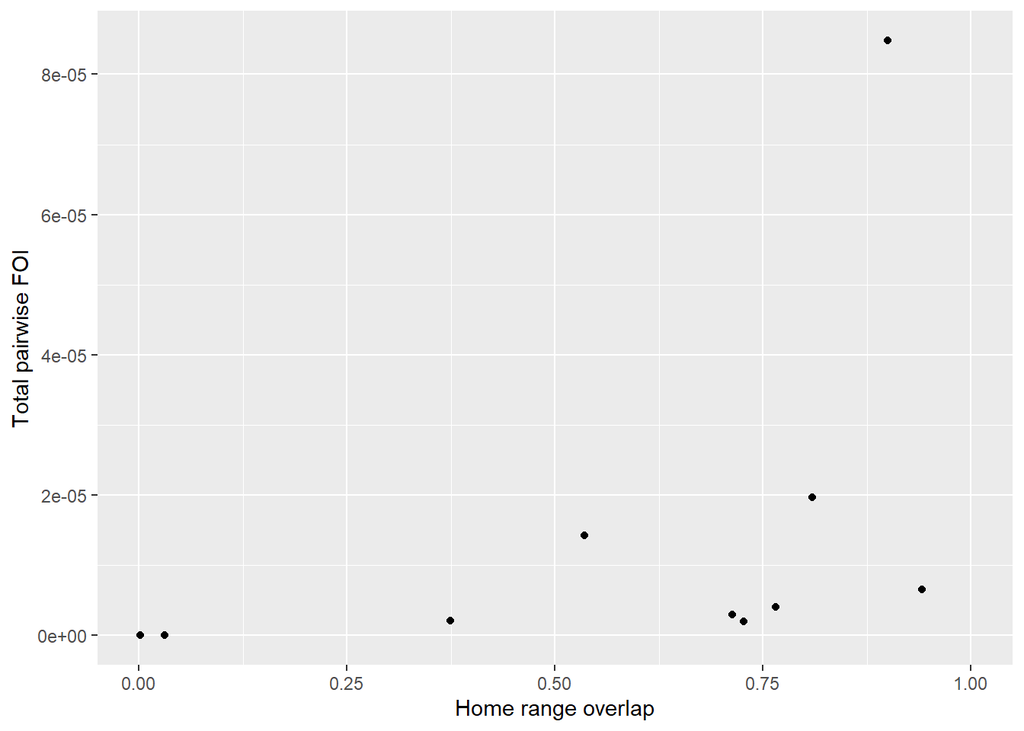

```r
ggplot(totfoisdf)+geom_point(aes(overlap, foi))+
  labs(x = "Home range overlap",
       y = "Total pairwise FOI")+
  lims(x = c(0,1))
```

## Pairwise FOI

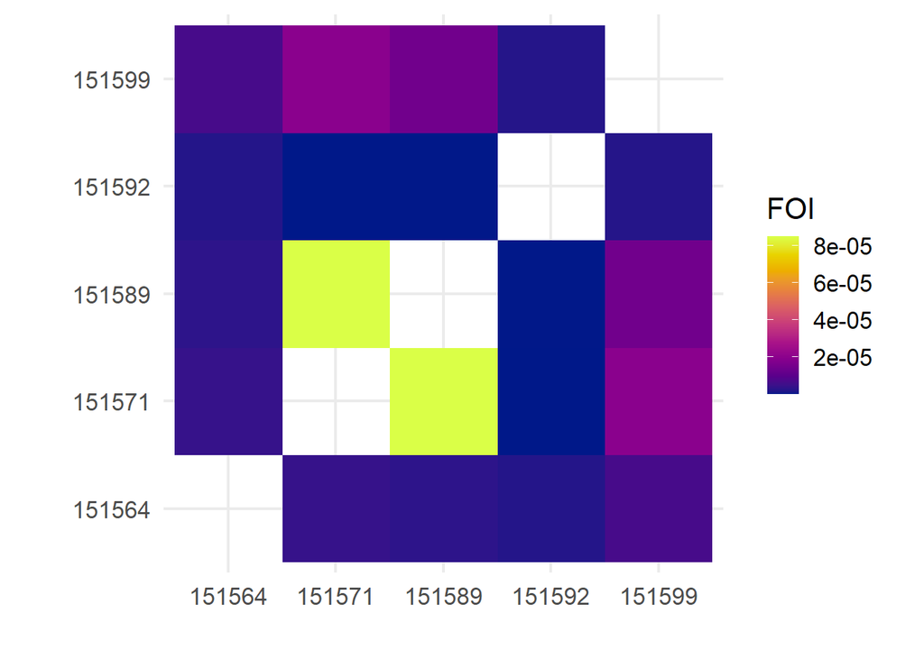

```r
ggplot(totfoisdf)+geom_raster(aes(ind1,ind2,fill=as.numeric(foi)))+
  coord_equal()+
  theme_minimal(base_size = 16)+
  labs(x = "", y="", fill = "FOI")+
  scale_fill_gradientn(colors = hcl.colors(10, "Plasma"))
```

Pairs with higher overlap have usually higher FOI, but there is one case that has a much higher FOI with similar overlap index. This pair is potentially a mother with its calf, so their movement should be highly correlated. How much of the FOI is due to the high spatial overlap, compared to the contribution of the temporal correlation?

# Contribution of correlation to FOI

We calculate the relative contribution of covariance/correlation to the local (cell) and overall pairwise FOI. In some cases the covariance term (SD product multiplied by correlation terms) is negative and greater than the product of the UDs. The cell FOI would become negative, which by definition is not possible. In these cases the contribution is set to equal the product of the UDs, but with negative sign. Here I calculate the contribution for three pairs: 151589 with 151571 (the mother-calf pair), 151599 with 151571, and 151564 with 151599.

```
## Total covariance relative contribution to FOI,  151571 151589 : 0.0002517066
```

```
## Total covariance relative contribution to FOI,  151571 151599 : 3.169739e-05
```

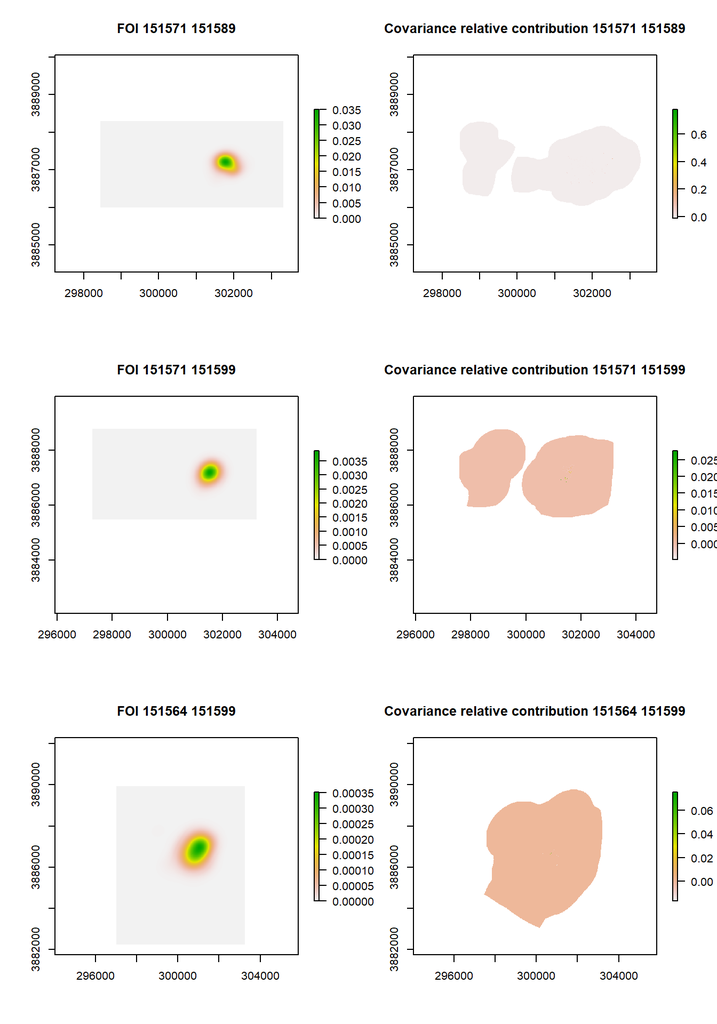

```
## Total covariance relative contribution to FOI,  151564 151599 : -1.534723e-05
```

```r
corrastfiles <- list.files("../outputs/", "Corrast(.*).tif$", full.names = T)
udprodfiles <- list.files("../outputs/", "UDprod(.*).tif$", full.names = T)
sdprodfiles <- list.files("../outputs/", "SDprod(.*).tif$", full.names = T)
par(mfrow = c(3,2))
for (i in c(3,5,2)) {
  ind1 = substr(basename(corrastfiles[i]),9,14)
  ind2 = substr(basename(corrastfiles[i]),16,21)
  corrast <- raster(corrastfiles[i])
  Area <- prod(res(corrast))
  # calculate scaled UD, and SD
  ud <- 1/nu*raster(udprodfiles[grepl(ind1, udprodfiles) & grepl(ind2, udprodfiles)])
  sd <- raster(sdprodfiles[grepl(ind1, sdprodfiles) & grepl(ind2, sdprodfiles)])
  # multiply SD product by integrated cross-corr
  covrast <- sd*corrast
  # quantify the absolute contribution: if the covariance term is positive, or
  # negative but with lower absolute value than the UD product then the value
  # stays the same. If it's negative and of greater magnitude than the UD, then
  # it's the opposite of the UD.
  contrib <- (covrast>=0)*covrast-(covrast<0&abs(covrast)>ud)*ud+(covrast<0&abs(covrast)<=ud)*covrast
  raster::plot(ud+covrast, main = paste("FOI",ind1,ind2))
  raster::plot(contrib/(ud+covrast), main = paste("Covariance relative contribution", ind1, ind2))
  cat("Total covariance relative contribution to FOI, ", ind1, ind2,":", cellStats(contrib,sum)/cellStats(ud+covrast, sum),"\n")
}
```

## Direct contact correlation

How would this be different if I focused only on direct contact? The UD and SD product remain the same, the difference is the number of lags considered. Here we explore how changing the number of lags considered affect the FOI estimation, and the estimated contribution from the covariance term. I will do this only for the pair that is travelling together. My time step is 30 minutes, I will explore correlations up to lag 2 (1 h lag), lag 48 (24 h), along with half of the maximum lag and the maximum lag. Instead of scaling the UD product by $1/\nu$, we scale by $\int_0^se^{-\nu \tau}d\tau=(1-e^{-\nu\tau})/\nu$

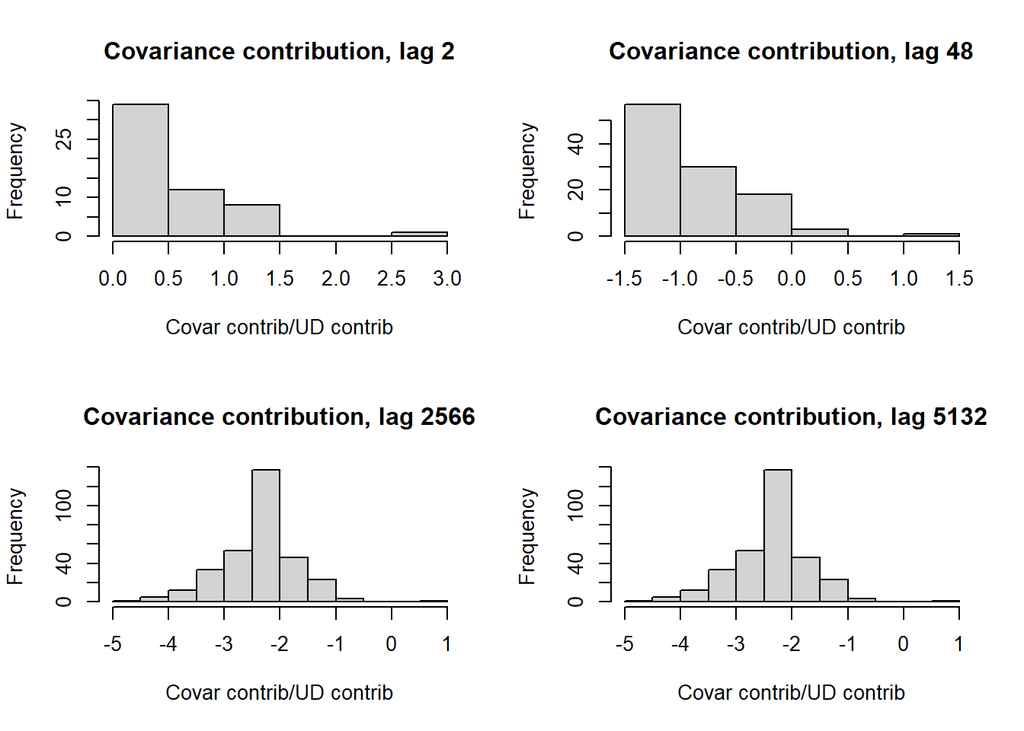

```r
cordat <- read.csv("../outputs/correlations_151571-151589.csv", row.names = 1)
maxlag <- nrow(cordat)-1
udprod <- raster("../outputs/UDprod_151571-151589.tif")
sdprod <- raster("../outputs/SDprod_151571-151589.tif")
par(mfrow = c(2,2))
for (lag in c(2,48,maxlag/2,maxlag)) {
  rowindex = lag+1
  # get lags in seconds
  lags <- (0:lag)*1800
  # select only the rows corresponding to the lags of interest
  d <- cordat[1:rowindex,]
  # create correlation raster based on the ud product raster, but set its values
  # to 0
  corrast <- udprod
  values(corrast) <- NA
  # calculate the scaled and integrated correlation term
  intcors <- colSums(d*exp(-nu*lags))
  # get the cell indices corresponding to the correlation values, substitute its
  # values in the raster
  corcells <- as.numeric(substring(names(cordat),2))
  corrast[corcells] <- intcors
  # multiply by the SD
  covrast <- sdprod*corrast
  # scale UD by decay. here I am using the solution of the integral int_0^x
  # e^(-nu t) dt, rather than 1/nu
  udscaled <- udprod*((1-exp(-nu*lag*1800))/nu)
  # estimate the local contribution.
  contrib <- (covrast>=0)*covrast-(covrast<0&abs(covrast)>udscaled)*udscaled+(covrast<0&abs(covrast)<=udscaled)*covrast

  hist(log10(contrib/udscaled), main = paste("Covariance contribution, lag",lag), xlab = "Covar contrib/UD contrib")
}
```

We also explore the case of direct transmission where the decay rate does not come into play. Here we only take the correlation at lag 0, multiply directly by the product of the SD, and add to the product of the UD.

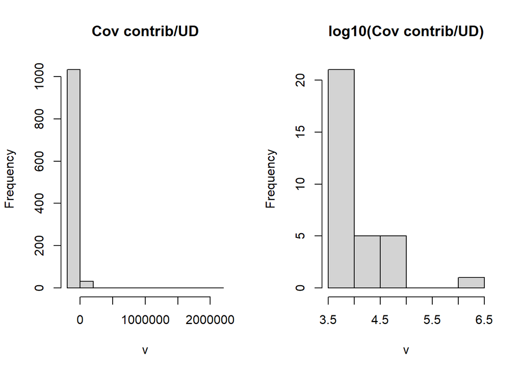

```r
cordat <- read.csv("../outputs/correlations_151571-151589.csv", row.names = 1)
udprod <- raster("../outputs/UDprod_151571-151589.tif")
sdprod <- raster("../outputs/SDprod_151571-151589.tif")
corrast <- udprod
values(corrast) <- NA
corcells <- as.numeric(substring(names(cordat),2))
corrast[corcells] <- as.numeric(cordat[1,])
covrast <- sdprod*corrast
contrib <- (covrast>=0)*covrast-(covrast<0&abs(covrast)>udprod)*udprod+(covrast<0&abs(covrast)<=udprod)*covrast
par(mfrow=c(1,2))
hist(contrib/udprod,  main = "Cov contrib/UD")
hist(log10(contrib/udprod), main = "log10(Cov contrib/UD)")
```

The case of direct transmission seems somewhat different. Again we get the covariance is negative and of greater magnitude for many cells, resulting in reducing the FOI to 0. For the other cells, however, the covariance is orders of magnitude greater than the UD product. The total FOI estimated is also 40.5511697 times greater with the covariance term than with the UD product alone.